# Week 10 Lab: Applications of Tidyverse Skills

AAI1001 – Data Engineering and Visualization  
AY24/25 Tri 2 (Assisted by GenAI)  
Exercise 5 (Teamwork 2)

Author

Affiliation

Team 12 (Lionel, Zhenming, Shaidah, Rachel, Cholo)

Singapore Institute of Technology

Published

Tuesday Mar 11, 2025

# 1 Converting Football Scores into a League Table (30%)

## 1.1 Generating a League Table

```r
epl_results <- read_csv("epl_results.csv", show_col_types = FALSE)
epl_teams <- read_csv("epl_teams.csv", show_col_types = FALSE)

# Convert match results to separate columns for home and away goals
epl_results_long <- epl_results %>%
  pivot_longer(-home_team, names_to = "away_team", values_to = "score") %>%
  separate(score, into = c("home_goals", "away_goals"), sep = "-", convert = TRUE)

# Compute match points
epl_results_long <- epl_results_long %>%
  mutate(
    home_points = case_when(
      home_goals > away_goals ~ 3,
      home_goals == away_goals ~ 1,
      TRUE ~ 0
    ),
    away_points = case_when(
      home_goals < away_goals ~ 3,
      home_goals == away_goals ~ 1,
      TRUE ~ 0
    )
  )

# Compute home and away statistics
home_stats <- epl_results_long %>%
  group_by(home_team) %>%
  summarise(
    points = sum(home_points, na.rm = TRUE),
    goals_scored = sum(home_goals, na.rm = TRUE),
    goals_conceded = sum(away_goals, na.rm = TRUE),
    .groups = "drop"
  ) %>%
  rename(team = home_team)

away_stats <- epl_results_long %>%
  group_by(away_team) %>%
  summarise(
    points = sum(away_points, na.rm = TRUE),
    goals_scored = sum(away_goals, na.rm = TRUE),
    goals_conceded = sum(home_goals, na.rm = TRUE),
    .groups = "drop"
  ) %>%
  rename(team = away_team)

# Combine home and away stats
total_stats <- full_join(home_stats, away_stats, by = "team", suffix = c("_home", "_away")) %>%
  mutate(
    points = points_home + points_away,
    goals_scored = goals_scored_home + goals_scored_away,
    goals_conceded = goals_conceded_home + goals_conceded_away,
    goal_diff = goals_scored - goals_conceded
  ) %>%
  select(team, points, goal_diff, goals_scored)

# Merge with team names
total_stats <- total_stats %>%
  left_join(epl_teams, by = c("team" = "abbr")) %>%
  select(name, points, goal_diff, goals_scored) %>%
  rename(team = name)

# Rank teams based on points, goal difference, and goals scored
epl_league_table <- total_stats %>%
  arrange(desc(points), desc(goal_diff), desc(goals_scored)) %>%
  mutate(rank = row_number()) %>%
  select(rank, team, points, goal_diff, goals_scored)

# Print the league table
epl_league_table
```

```
# A tibble: 20 × 5
    rank team                    points goal_diff goals_scored
   <int> <chr>                    <dbl>     <int>        <int>
 1     1 Liverpool                   99        52           85
 2     2 Manchester City             81        67          102
 3     3 Manchester United           66        30           66
 4     4 Chelsea                     66        15           69
 5     5 Leicester City              62        26           67
 6     6 Tottenham Hotspur           59        14           61
 7     7 Wolverhampton Wanderers     59        11           51
 8     8 Arsenal                     56         8           56
 9     9 Sheffield United            54         0           39
10    10 Burnley                     54        -7           43
11    11 Southampton                 52        -9           51
12    12 Everton                     49       -12           44
13    13 Newcastle United            44       -20           38
14    14 Crystal Palace              43       -19           31
15    15 Brighton & Hove Albion      41       -15           39
16    16 West Ham United             39       -13           49
17    17 Aston Villa                 35       -26           41
18    18 Bournemouth                 34       -25           40
19    19 Watford                     34       -28           36
20    20 Norwich City                21       -49           26
```

## 1.2 Improving the Visualization Using gt Functions

```r
# Create a nicely formatted table using gt
epl_league_table %>%
  gt() %>%
  tab_header(
    title = md("**EPL League Table**"),
    subtitle = "Rankings based on points, goal difference, and goals scored"
  ) %>%
  cols_label(
    rank = "Rank",
    team = "Team",
    points = "Points",
    goal_diff = "Goal Difference",
    goals_scored = "Goals Scored"
  ) %>%
  tab_style(
    style = cell_text(weight = "bold"),
    locations = cells_column_labels(everything())
  ) %>%
  tab_options(
    table.font.size = px(14),
    table.width = pct(100),
    row.striping.include_table_body = TRUE,
    row.striping.background_color = "#f2f2f2"
  ) %>%
  tab_style(
    style = cell_fill(color = "#A3E4D7"),
    locations = cells_body(rows = rank <= 4)
  ) %>%
  tab_style(
    style = cell_fill(color = "#F5B7B1"),
    locations = cells_body(rows = rank >= 18)
  ) %>%
  tab_style(
    style = cell_text(weight = "bold"),
    locations = cells_body(rows = rank == 1, columns = team)
  ) %>%
  tab_footnote(
    footnote = md("<span style='color:#A3E4D7'><strong>Top 4 qualified</strong></span> for the Champions League group stage"),
    locations = cells_column_labels(columns = rank)
  ) %>%
  tab_footnote(
    footnote = md("<span style='color:#F5B7B1'><strong>Bottom 3 relegated</strong></span>  EFL Championship"),
    locations = cells_column_labels(columns = rank)
  ) %>%
  tab_source_note(
    source_note = md("Source: [Wikipedia](https://en.wikipedia.org/wiki/2019%E2%80%9320_Premier_League#League_table)")
  )
```

**EPL League Table**

Rankings based on points, goal difference, and goals scored

| Rank<sup>1,2</sup> | Team | Points | Goal Difference | Goals Scored |
| --- | --- | --- | --- | --- |
| 1 | Liverpool | 99 | 52 | 85 |
| 2 | Manchester City | 81 | 67 | 102 |
| 3 | Manchester United | 66 | 30 | 66 |
| 4 | Chelsea | 66 | 15 | 69 |
| 5 | Leicester City | 62 | 26 | 67 |
| 6 | Tottenham Hotspur | 59 | 14 | 61 |
| 7 | Wolverhampton Wanderers | 59 | 11 | 51 |
| 8 | Arsenal | 56 | 8 | 56 |
| 9 | Sheffield United | 54 | 0 | 39 |
| 10 | Burnley | 54 | -7 | 43 |
| 11 | Southampton | 52 | -9 | 51 |
| 12 | Everton | 49 | -12 | 44 |
| 13 | Newcastle United | 44 | -20 | 38 |
| 14 | Crystal Palace | 43 | -19 | 31 |
| 15 | Brighton & Hove Albion | 41 | -15 | 39 |
| 16 | West Ham United | 39 | -13 | 49 |
| 17 | Aston Villa | 35 | -26 | 41 |
| 18 | Bournemouth | 34 | -25 | 40 |
| 19 | Watford | 34 | -28 | 36 |
| 20 | Norwich City | 21 | -49 | 26 |

Source: [Wikipedia](https://en.wikipedia.org/wiki/2019%E2%80%9320_Premier_League#League_table)  
<sup>1</sup> **Top 4 qualified** for the Champions League group stage  
<sup>2</sup> **Bottom 3 relegated** EFL Championship

# 2 Exercise 2: Finding and Visualizing a Real-World Data Set (30%)

## 2.1 Explanation of the Data Set

> The dataset `Resale Flat Prices (Based on Approval Date), 1990 - 1999.csv` entails Historical Resale HDB price. Each row represents a single resale transaction, and each column represents an aspect of the resale transaction, including `year-month`, `town`, `flat type`, `storey range`, `flat model` etc. etc. The entire dataset has 200,000 rows of data between 1990 to 1999, of all locations in Singapore. For the purpose of this exercise, we are only looking at **Ang Mo Kio** HDBs in **1990**.

```r
resale_flats <- read.csv("Resale Flat Prices (Based on Approval Date), 1990 - 1999.csv")
head(resale_flats)
```

```
    month       town flat_type block      street_name storey_range
1 1990-01 ANG MO KIO    1 ROOM   309 ANG MO KIO AVE 1     10 TO 12
2 1990-01 ANG MO KIO    1 ROOM   309 ANG MO KIO AVE 1     04 TO 06
3 1990-01 ANG MO KIO    1 ROOM   309 ANG MO KIO AVE 1     10 TO 12
4 1990-01 ANG MO KIO    1 ROOM   309 ANG MO KIO AVE 1     07 TO 09
5 1990-01 ANG MO KIO    3 ROOM   216 ANG MO KIO AVE 1     04 TO 06
6 1990-01 ANG MO KIO    3 ROOM   211 ANG MO KIO AVE 3     01 TO 03
  floor_area_sqm     flat_model lease_commence_date resale_price
1             31       IMPROVED                1977         9000
2             31       IMPROVED                1977         6000
3             31       IMPROVED                1977         8000
4             31       IMPROVED                1977         6000
5             73 NEW GENERATION                1976        47200
6             67 NEW GENERATION                1977        46000
```

```r
filtered_data <- resale_flats |>
  filter(town == "ANG MO KIO") |>
  filter(str_starts(month, "1990"))

head(filtered_data)
```

```
    month       town flat_type block      street_name storey_range
1 1990-01 ANG MO KIO    1 ROOM   309 ANG MO KIO AVE 1     10 TO 12
2 1990-01 ANG MO KIO    1 ROOM   309 ANG MO KIO AVE 1     04 TO 06
3 1990-01 ANG MO KIO    1 ROOM   309 ANG MO KIO AVE 1     10 TO 12
4 1990-01 ANG MO KIO    1 ROOM   309 ANG MO KIO AVE 1     07 TO 09
5 1990-01 ANG MO KIO    3 ROOM   216 ANG MO KIO AVE 1     04 TO 06
6 1990-01 ANG MO KIO    3 ROOM   211 ANG MO KIO AVE 3     01 TO 03
  floor_area_sqm     flat_model lease_commence_date resale_price
1             31       IMPROVED                1977         9000
2             31       IMPROVED                1977         6000
3             31       IMPROVED                1977         8000
4             31       IMPROVED                1977         6000
5             73 NEW GENERATION                1976        47200
6             67 NEW GENERATION                1977        46000
```

## 2.2 Validation of Conditions C, D, and E

> Condition C : At least 100 observations

```r
nrow(filtered_data)
```

```
[1] 1628
```

> Condition D : At least 2 numeric variables

```r
head(
  filtered_data |>
  select(floor_area_sqm, resale_price)
)
```

```
  floor_area_sqm resale_price
1             31         9000
2             31         6000
3             31         8000
4             31         6000
5             73        47200
6             67        46000
```

> Condition E : At least one pair of identical / nearly-identical values

```r
duplicates <- filtered_data |>  # Filter for Ang Mo Kio
  select(floor_area_sqm, resale_price) |>  # Keep relevant columns
  group_by(floor_area_sqm, resale_price) |>
  summarise(count = n(), .groups = "drop") |>  # Count occurrences properly
  filter(count > 1) |>  # Keep only duplicates
  arrange(desc(count))  # Sort by highest count

duplicates
```

```
# A tibble: 203 × 3
   floor_area_sqm resale_price count
            <dbl>        <int> <int>
 1             67        47000   148
 2             68        47000    95
 3             73        47000    48
 4             67        47200    38
 5             82        57000    31
 6             68        47200    30
 7             67        45000    23
 8             92        72000    22
 9             67        40000    21
10             74        47000    20
# ℹ 193 more rows
```

## 2.3 Generating a Scatter Plot Using `geom_point()`

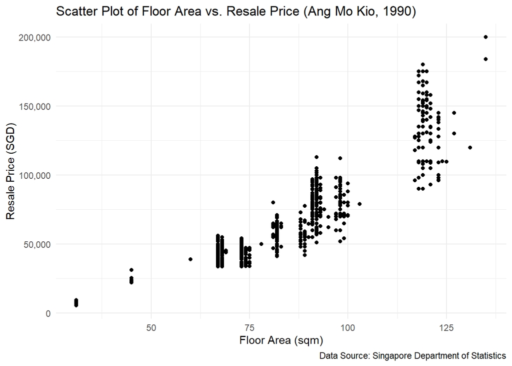

```r
# Generate scatter plot using filtered data (Ang Mo Kio, 1990)
ggplot(filtered_data, aes(x = floor_area_sqm, y = resale_price)) +
  geom_point() +
  scale_y_continuous(labels = comma_format()) +  # Format y-axis to avoid scientific notation
  labs(
    title = "Scatter Plot of Floor Area vs. Resale Price (Ang Mo Kio, 1990)",
    x = "Floor Area (sqm)",
    y = "Resale Price (SGD)",
    caption = "Data Source: Singapore Department of Statistics"
  ) +
  theme_minimal()
```

## 2.4 Producing and Discussing Two Distinct Plots Designed to Mitigate Overplotting

### 2.4.1 Scatter Plot with Transparency

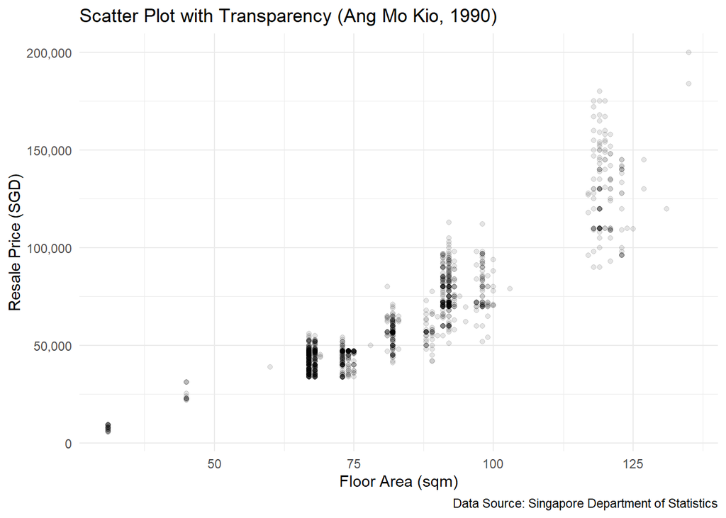

```r
ggplot(filtered_data, aes(x = floor_area_sqm, y = resale_price)) +
  geom_point(alpha = 0.1) +  # Reduces opacity to show density
  scale_y_continuous(labels = scales::comma_format()) +
  labs(
    title = "Scatter Plot with Transparency (Ang Mo Kio, 1990)",
    x = "Floor Area (sqm)",
    y = "Resale Price (SGD)",
    caption = "Data Source: Singapore Department of Statistics"
  ) +
  theme_minimal()
```

#### ✅ Advantages:

- Reveals **density regions** clearly.
- Keeps **actual data points** visible.

#### ❌ Disadvantages:

- In **highly dense** areas, points still **overlap**.

### 2.4.2 Scatter Plot with Jittering

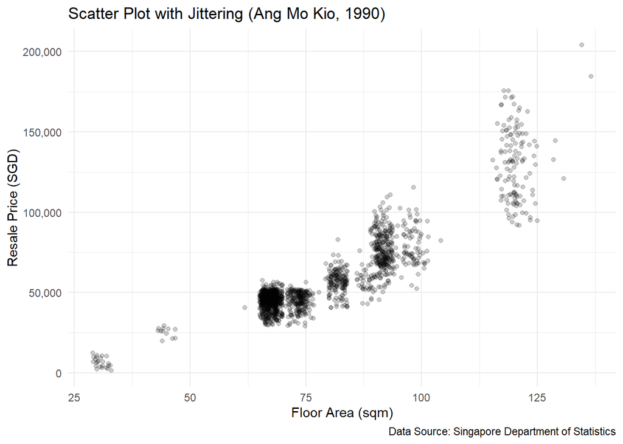

```r
ggplot(filtered_data, aes(x = floor_area_sqm, y = resale_price)) +
  geom_jitter(width = 2, height = 5000, alpha = 0.2) +  # Adds slight randomness
  scale_y_continuous(labels = scales::comma_format()) +
  labs(
    title = "Scatter Plot with Jittering (Ang Mo Kio, 1990)",
    x = "Floor Area (sqm)",
    y = "Resale Price (SGD)",
    caption = "Data Source: Singapore Department of Statistics"
  ) +
  theme_minimal()
```

## 2.5 Creating Two Distinct Smoothing Interpolations

### 2.5.1 Linear Regression Smoothing

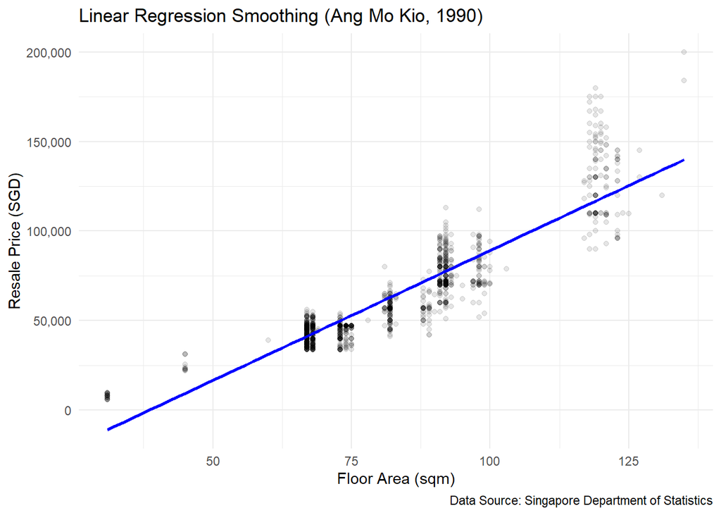

```r
ggplot(filtered_data, aes(x = floor_area_sqm, y = resale_price)) +
  geom_point(alpha = 0.1) +
  geom_smooth(method = "lm", se = FALSE, color = "blue") +  # Linear trend line
  scale_y_continuous(labels = scales::comma_format()) +
  labs(
    title = "Linear Regression Smoothing (Ang Mo Kio, 1990)",
    x = "Floor Area (sqm)",
    y = "Resale Price (SGD)",
    caption = "Data Source: Singapore Department of Statistics"
  ) +
  theme_minimal()
```

#### ✅ Advantages:

- **Simple and interpretable**.
- Clearly shows **linear relationships**.

#### ❌ Disadvantages:

- **Cannot capture non-linear trends** in the data.

### 2.5.2 LOESS (Locally Estimated ScatterPlot Smoothing)

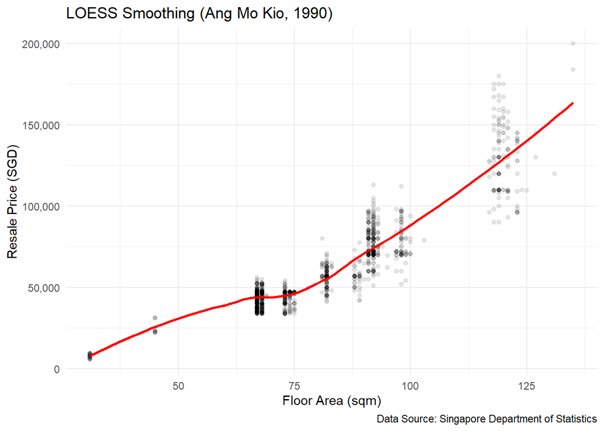

```r
ggplot(filtered_data, aes(x = floor_area_sqm, y = resale_price)) +
  geom_point(alpha = 0.1) +
  geom_smooth(method = "loess", se = FALSE, color = "red") +  # LOESS smoothing
  scale_y_continuous(labels = scales::comma_format()) +
  labs(
    title = "LOESS Smoothing (Ang Mo Kio, 1990)",
    x = "Floor Area (sqm)",
    y = "Resale Price (SGD)",
    caption = "Data Source: Singapore Department of Statistics"
  ) +
  theme_minimal()
```

#### ✅ Advantages:

- Captures **non-linear relationships** better than linear regression.

#### ❌ Disadvantages:

- **Sensitive to outliers** and **computationally expensive** for large datasets.

# 3 Visualizing Michelson’s Speed-of-Light Measurements (25%)

## 3.1 Converting the `Expt` Column to a Factor

```r
# Load the morley dataset
data(morley)

# Convert the dataset to a tibble
morley <- as_tibble(morley)

# Convert the Expt column to a factor
morley <- morley |>
  mutate(Expt = as.factor(Expt))

# Display the updated tibble
print(morley)
```

```
# A tibble: 100 × 3
   Expt    Run Speed
   <fct> <int> <int>
 1 1         1   850
 2 1         2   740
 3 1         3   900
 4 1         4  1070
 5 1         5   930
 6 1         6   850
 7 1         7   950
 8 1         8   980
 9 1         9   980
10 1        10   880
# ℹ 90 more rows
```

## 3.2 Scatter Plot: Experiment Number versus Measured Speeds

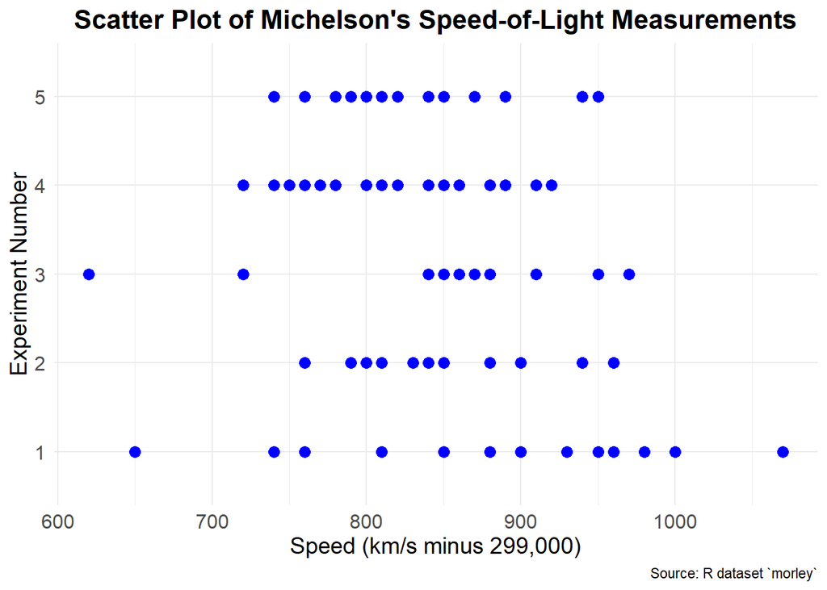

```r
# Ensure Expt is a factor
morley <- morley |>
  mutate(Expt = as.factor(Expt))

# Create the scatter plot using ggplot2
scatter_plot <- morley |>
  ggplot(aes(x = Speed, y = Expt)) +
  geom_point(size = 3, color = "blue") +  # Customize point size, transparency, and color
  labs(
    title = "Scatter Plot of Michelson's Speed-of-Light Measurements",
    x = "Speed (km/s minus 299,000)",
    y = "Experiment Number",
    caption = "Source: R dataset `morley`"
  ) +
  theme_minimal() +  # Use a minimal theme for a clean look
  theme(
    plot.title = element_text(size = 16, face = "bold", hjust = 0.5),  # Customize title
    axis.title = element_text(size = 14),  # Customize axis titles
    axis.text = element_text(size = 12)  # Customize axis text
  )

# Display the scatter plot
print(scatter_plot)
```

## 3.3 Creating a Box Plot with One Box per Experiment

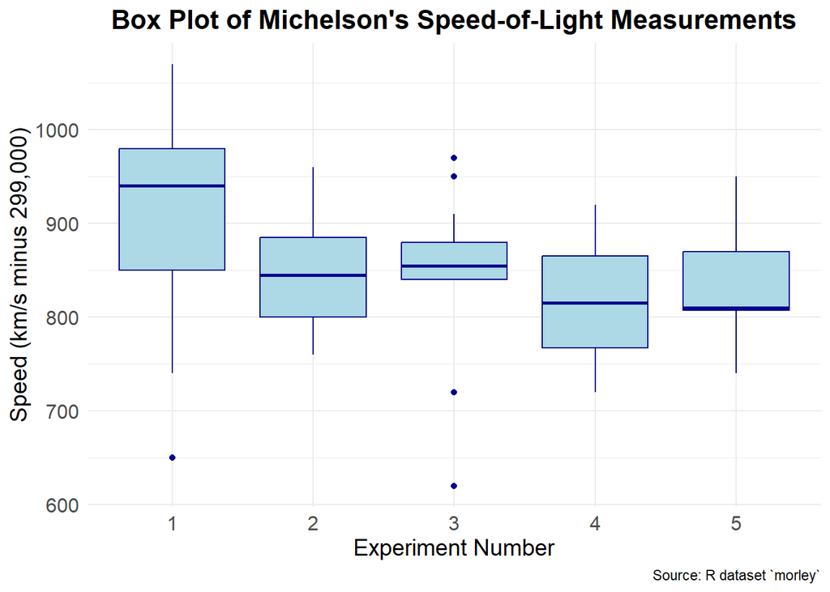

```r
# Create the box plot using ggplot2
box_plot <- morley |>
  ggplot(aes(x = Expt, y = Speed)) +
  geom_boxplot(fill = "lightblue", color = "darkblue") +  # Customize box plot colors
  labs(
    title = "Box Plot of Michelson's Speed-of-Light Measurements",
    x = "Experiment Number",
    y = "Speed (km/s minus 299,000)",
    caption = "Source: R dataset `morley`"
  ) +
  theme_minimal() +  # Use a minimal theme for a clean look
  theme(
    plot.title = element_text(size = 16, face = "bold", hjust = 0.5),  # Customize title
    axis.title = element_text(size = 14),  # Customize axis titles
    axis.text = element_text(size = 12)  # Customize axis text
  )

# Display the box plot
print(box_plot)
```

## 3.4 Inserting a Violin Plot into the Box Plot

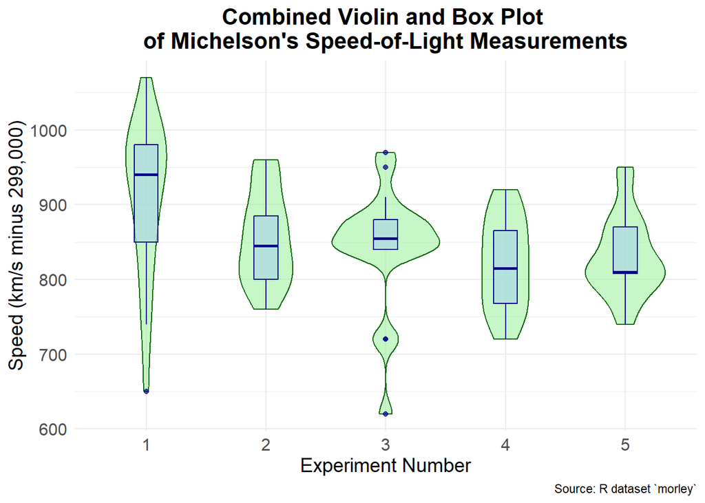

```r
# Create the combined violin and box plot using ggplot2
combined_plot <- morley |>
  ggplot(aes(x = Expt, y = Speed)) +
  geom_violin(fill = "lightgreen", color = "darkgreen", alpha = 0.5) +  # Add violin plot
  geom_boxplot(width = 0.2, fill = "lightblue", color = "darkblue", alpha = 0.7) +  # Add box plot
  labs(
    title = "Combined Violin and Box Plot \nof Michelson's Speed-of-Light Measurements",
    x = "Experiment Number",
    y = "Speed (km/s minus 299,000)",
    caption = "Source: R dataset `morley`"
  ) +
  theme_minimal() +  # Use a minimal theme for a clean look
  theme(
    plot.title = element_text(size = 16, face = "bold", hjust = 0.5),  # Customize title
    axis.title = element_text(size = 14),  # Customize axis titles
    axis.text = element_text(size = 12)  # Customize axis text
  )

# Display the combined plot
print(combined_plot)
```

## 3.5 Creating a Faceted Plot Displaying Histograms

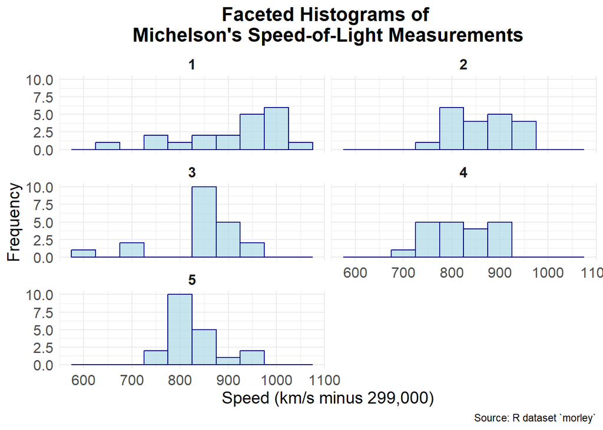

```r
# Create the faceted histogram plot using ggplot2
faceted_histogram_plot <- morley |>
  ggplot(aes(x = Speed)) +
  geom_histogram(binwidth = 50, fill = "lightblue", color = "darkblue", alpha = 0.7) +  # Add histograms
  facet_wrap(~ Expt, ncol = 2) +  # Create facets for each experiment
  labs(
    title = "Faceted Histograms of \nMichelson's Speed-of-Light Measurements",
    x = "Speed (km/s minus 299,000)",
    y = "Frequency",
    caption = "Source: R dataset `morley`"
  ) +
  theme_minimal() +  # Use a minimal theme for a clean look
  theme(
    plot.title = element_text(size = 16, face = "bold", hjust = 0.5),  # Customize title
    axis.title = element_text(size = 14),  # Customize axis titles
    axis.text = element_text(size = 12),  # Customize axis text
    strip.text = element_text(size = 12, face = "bold")  # Customize facet labels
  )

# Display the faceted histogram plot
print(faceted_histogram_plot)
```

## 3.6 Discussion of the Plots

The combined violin and box plot provides the most comprehensive view of the data. It not only shows the distribution shape using the violin plot but also summarizes the central tendency and spread with the box plot. It is particularly useful for identifying outliers and understanding the density of measurements within each experiment.

# 4 Exercise 4: Reflection on the Use of GenAI (10%)

For this assessment, our team used **DeepSeek** and **ChatGPT** to assist with various tasks. These tools helped speed up our work and provided useful insights, especially for debugging **R** code and understanding statistical methods. We also used **GitHub** for collaboration, which made teamwork and version control more efficient.

The main benefit of **GenAI** was its ability to save us the time and effort used for recalling code syntax. Tasks like writing and debugging code were completed faster, and the tools offered clear explanations for unfamiliar concepts, such as **ggplot2** and **tidyverse** syntax. This made it easier to learn while working.

However, there were some challenges. The tools occasionally provided **generic solutions** that needed adjustments to fit our specific needs. They also sometimes lacked **domain-specific depth**, requiring us to refine their outputs.

Overall, **GenAI** was a helpful resource. It allowed us to focus on **higher-level problem-solving**, but it worked best when combined with **human judgment**.